# MCC Informativeness - summary pilots kids

Manuel Bohn

7 2 2018

# Overview by experiment

## Experiment descriptions

- 1_round1: Table setup (like adults) including control trials (4 objects)
- 2_filler: Table setup without control trials but with filler trials
- 3_move_agent: Table setup with agent moving in front of table before asking
- 4_move_turn: Table setup with agent turning to the other table before moving to the target table and requesting
- 5_new_wording: Table setup with experimenter reading out prompts. Wording changed to “Here is a table with a dax”.
- 6_robot_look: Robot setup with experimenter reading prompts. Agent looks to robot when making request. Wording (from here onwards): “This is a robot with a dax”.
- 7_robot_point: Robot setup, experimenter reading prompts. Agent points twice while labeling and before requesting.
- 8_robot_point_talk: Robot setup, recorded request. Pointing twice to target robot before requesting.
- 9_robot_map_container: Robot setup, recorded request. Pointing twice during labeling. Children pick container instead of object directly.

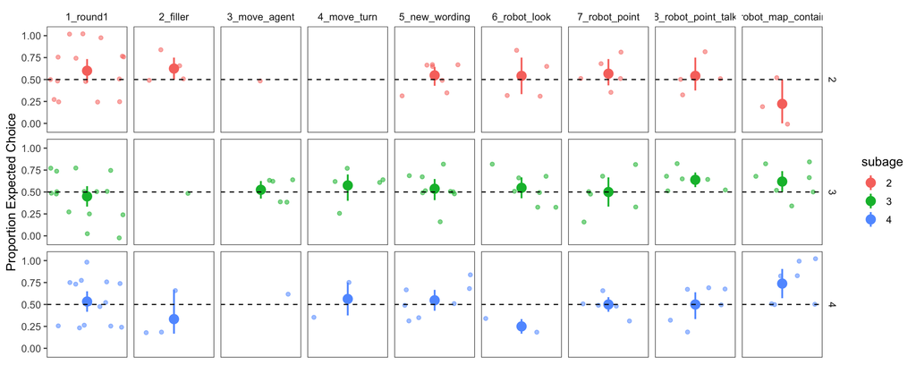

# Model across experiments

```r
library(lme4)

lm <- glmer(correct ~ subage * setup + subage * move + subage * turn + subage * wording + subage * filler + subage * choice + (subage  | agent) + (subage | experiment) + (1 | subid),
              data = pilot_data, family = binomial,
              control=glmerControl(optimizer="bobyqa",optCtrl=list(maxfun=2e5)))
```

```
## fixed-effect model matrix is rank deficient so dropping 1 column / coefficient
```

```r
summary(lm)
```

```
## Generalized linear mixed model fit by maximum likelihood (Laplace
##   Approximation) [glmerMod]
##  Family: binomial  ( logit )
## Formula:
## correct ~ subage * setup + subage * move + subage * turn + subage *
##     wording + subage * filler + subage * choice + (subage | agent) +
##     (subage | experiment) + (1 | subid)
##    Data: pilot_data
## Control:
## glmerControl(optimizer = "bobyqa", optCtrl = list(maxfun = 2e+05))
##
##      AIC      BIC   logLik deviance df.resid
##   1221.3   1378.1   -577.6   1155.3      823
##
## Scaled residuals:
##     Min      1Q  Median      3Q     Max
## -1.6790 -1.0774  0.6627  0.9016  1.8781
##
## Random effects:
##  Groups     Name        Variance  Std.Dev.  Corr
##  subid      (Intercept) 3.269e-14 1.808e-07
##  agent      (Intercept) 1.625e-01 4.031e-01
##             subage3     7.240e-02 2.691e-01 -1.00
##             subage4     9.746e-02 3.122e-01 -1.00  1.00
##  experiment (Intercept) 0.000e+00 0.000e+00
##             subage3     1.360e-14 1.166e-07  NaN
##             subage4     4.474e-16 2.115e-08  NaN  0.83
## Number of obs: 856, groups:  subid, 153; agent, 12; experiment, 9
##
## Fixed effects:
##                               Estimate Std. Error z value Pr(>|z|)
## (Intercept)                   -1.35659    1.06706  -1.271 0.203611
## subage3                        2.22305    1.14223   1.946 0.051626 .
## subage4                        2.82816    1.33364   2.121 0.033953 *
## setuptable                     0.70830    1.07449   0.659 0.509769
## moveno_move                    0.37595    0.77338   0.486 0.626885
## turnturn                      -0.62695    1.25086  -0.501 0.616222
## wordingthere_is_a_dax         -0.76742    0.81841  -0.938 0.348399
## fillerno_filler               -0.04077    0.51560  -0.079 0.936970
## choiceobject                   1.46755    0.61282   2.395 0.016632 *
## subage3:setuptable            -1.41597    1.14913  -1.232 0.217870
## subage4:setuptable            -0.55741    0.83308  -0.669 0.503434
## subage3:moveno_move           -0.66356    0.87628  -0.757 0.448902
## subage4:moveno_move           -0.74803    1.09562  -0.683 0.494768
## subage3:turnturn               0.84837    1.32896   0.638 0.523233
## subage4:turnturn               0.36751    1.35786   0.271 0.786656
## subage3:wordingthere_is_a_dax  1.08719    1.26004   0.863 0.388234
## subage3:fillerno_filler       -0.10990    1.00081  -0.110 0.912558
## subage4:fillerno_filler        0.86533    0.76457   1.132 0.257728
## subage3:choiceobject          -1.70638    0.71576  -2.384 0.017126 *
## subage4:choiceobject          -2.64713    0.73940  -3.580 0.000343 ***
## ---
## Signif. codes:  0 '***' 0.001 '**' 0.01 '*' 0.05 '.' 0.1 ' ' 1
```

```
##
## Correlation matrix not shown by default, as p = 20 > 12.
## Use print(x, correlation=TRUE)  or
##   vcov(x)     if you need it
```

```
## fit warnings:
## fixed-effect model matrix is rank deficient so dropping 1 column / coefficient
```

# Indivudal variations

## Setup

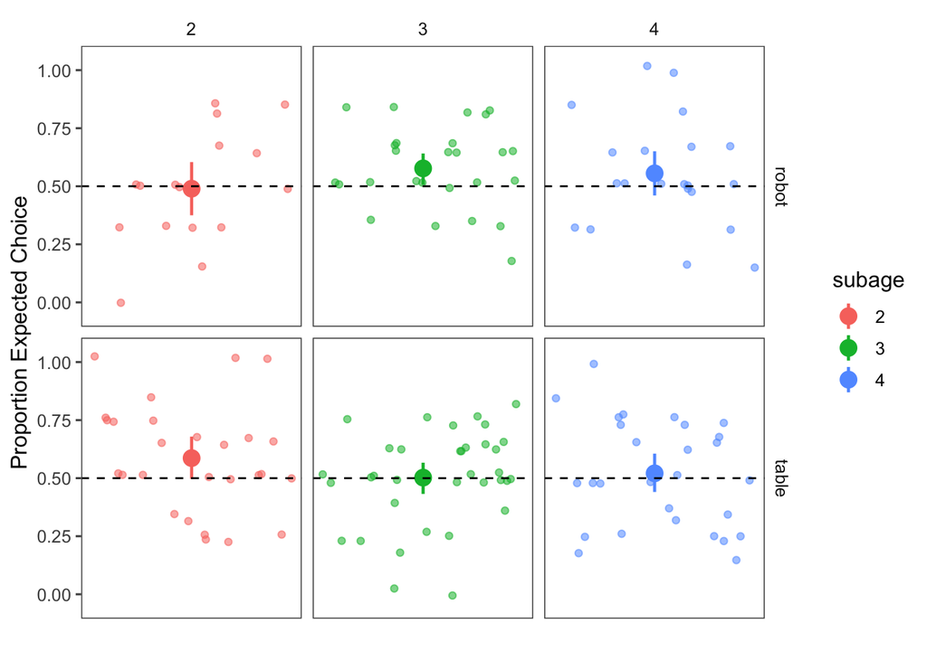

## Wording

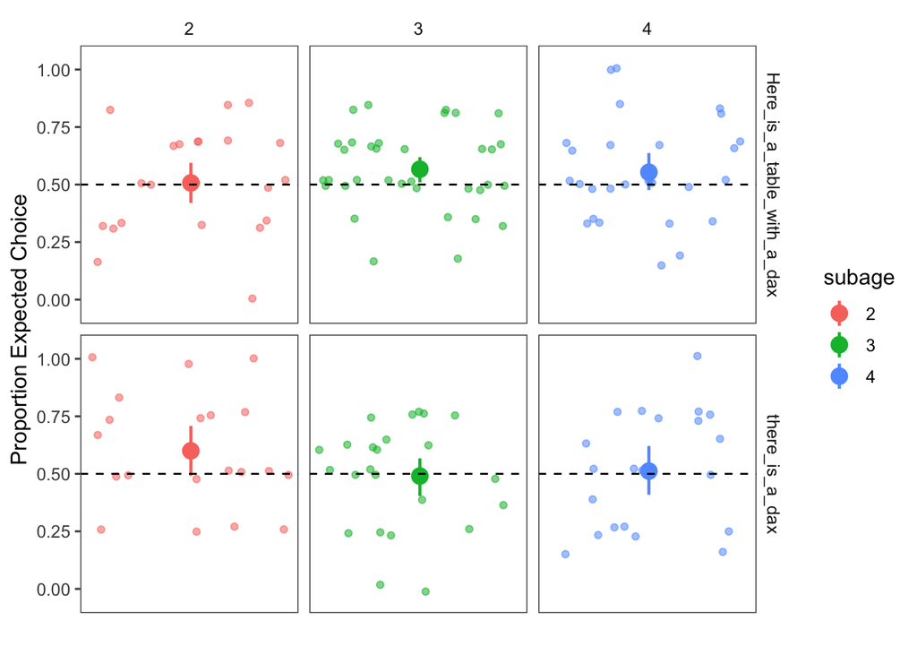

## Move (only table setup)

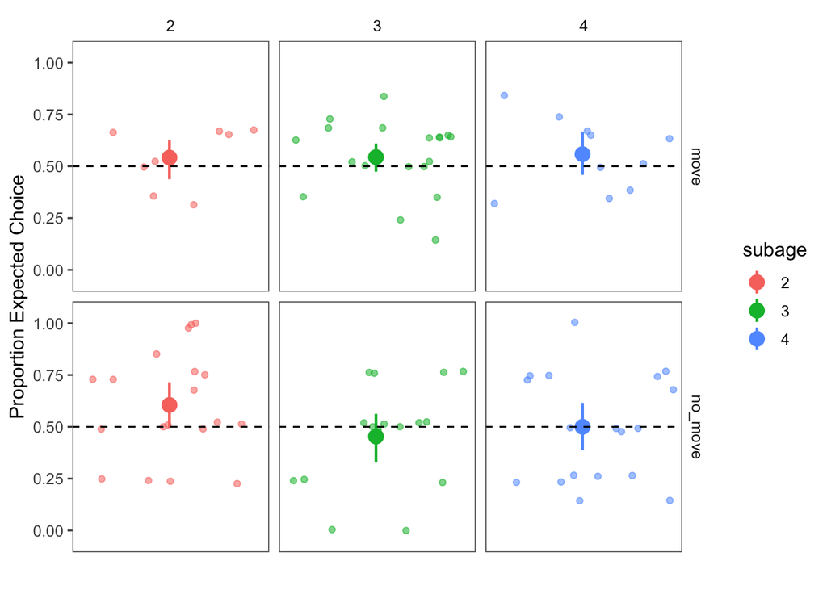

## Filler

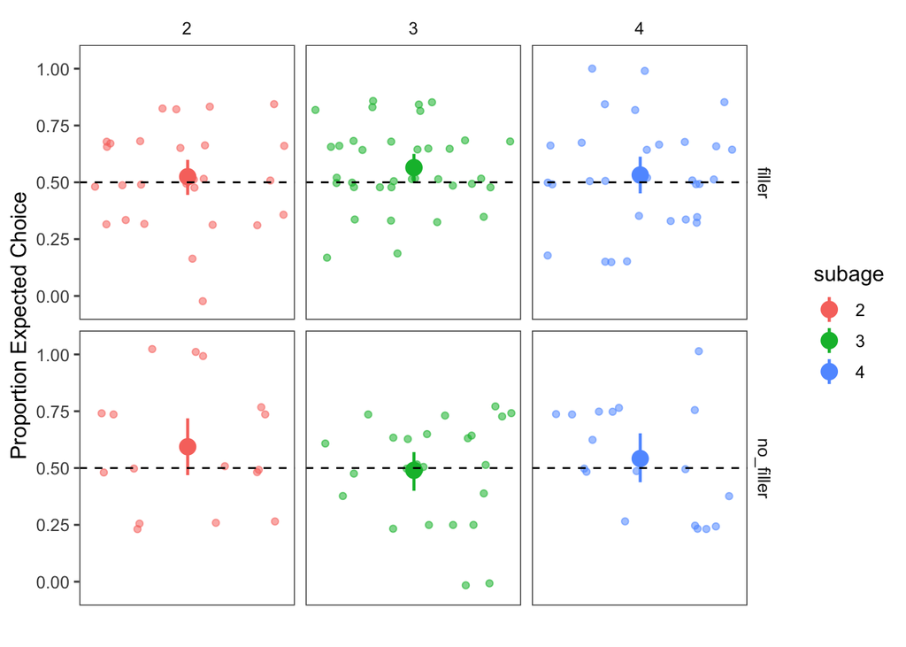